# Hw2

# 7.5.3.1 Exercises

**1. Instead of summarising the conditional distribution with a boxplot, you could use a frequency polygon. What do you need to consider when using cut_width() vs cut_number()? How does that impact a visualisation of the 2d distribution of carat and price?**

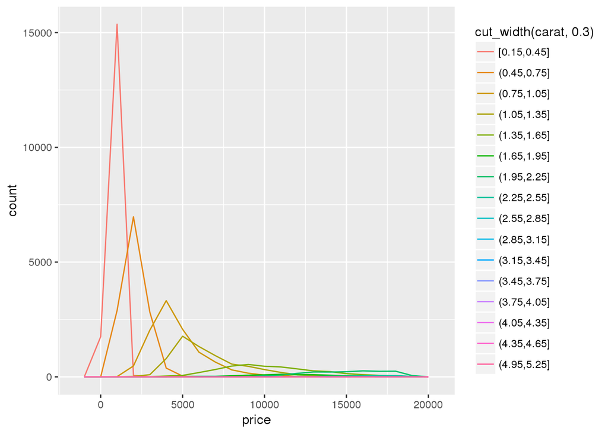

```r
ggplot(data = diamonds,
       mapping = aes(x = price,
                     colour = cut_width(carat, 0.3))) +
  geom_freqpoly(binwidth = 1000)
```

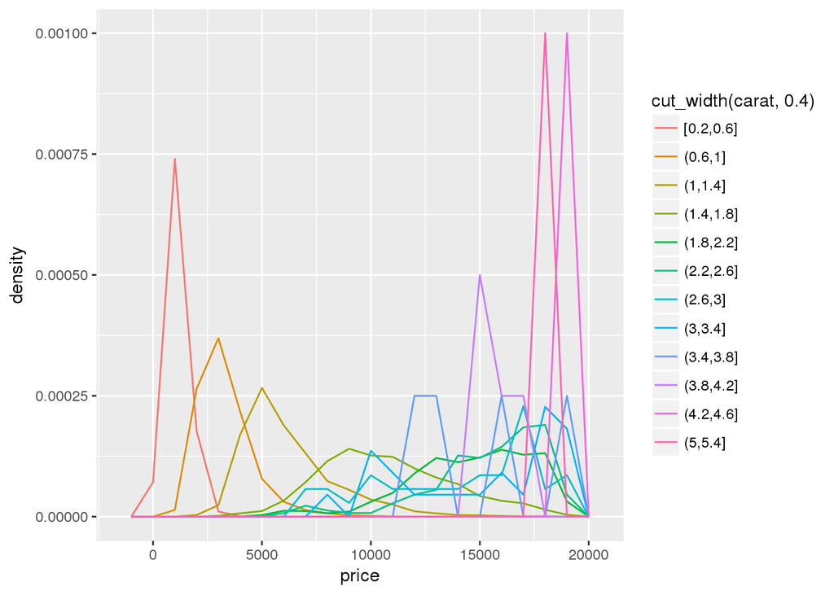

```r
ggplot(data = diamonds,
       mapping = aes(x = price,
                     y = ..density..,
                     colour = cut_width(carat, 0.4))) +
  geom_freqpoly(binwidth = 1000)
```

One thing to take into consideration is using counts vs. density for cut_width. It is difficult to compare counts of diamonds since there are so few counts of high priced diamonds, so it is hard to visualize them on the frequency polygon. On the other hand, using density to compare diamond price allows for better comparison of the majority of smaller diamonds vs. the few high priced diamonds.

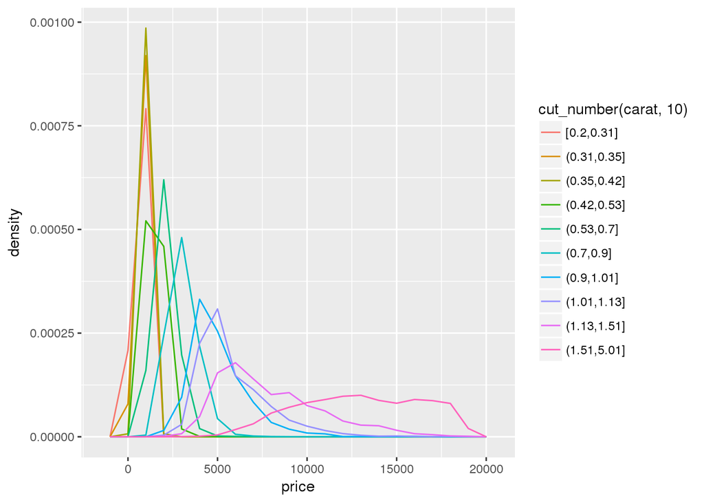

```r
ggplot(data = diamonds, mapping = aes(x = price,
      y = ..density.., color = cut_number(carat, 10))) +
  geom_freqpoly(binwidth = 1000)
```

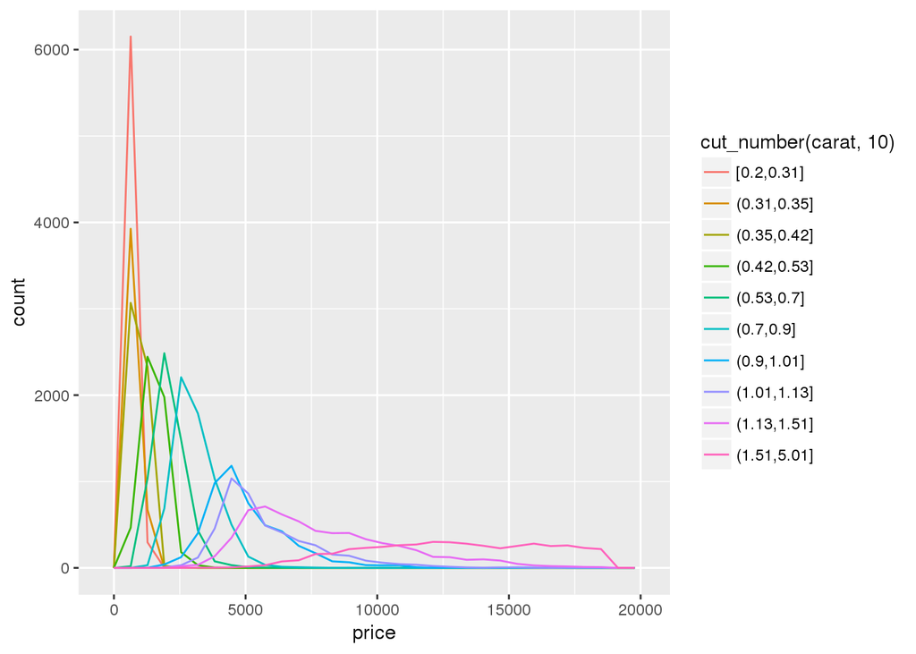

```r
ggplot(data = diamonds, mapping = aes(x = price,
      colour = cut_number(carat, 10))) +
  geom_freqpoly(binwidht = 1000)
```

Using cut_number, the two frequency polygons look very similar. This is because cut_number “divides the data into n groups, with (approximately) equal numbers of observations.” (Source: http://ggplot2.tidyverse.org/reference/cut_interval.html). On the other hand, cut_width does NOT divide the data into n groups with equal numbers of observations. Instead, cut_width makes groups of a width the user specifies.

**2. Visualise the distribution of carat, partitioned by price.**

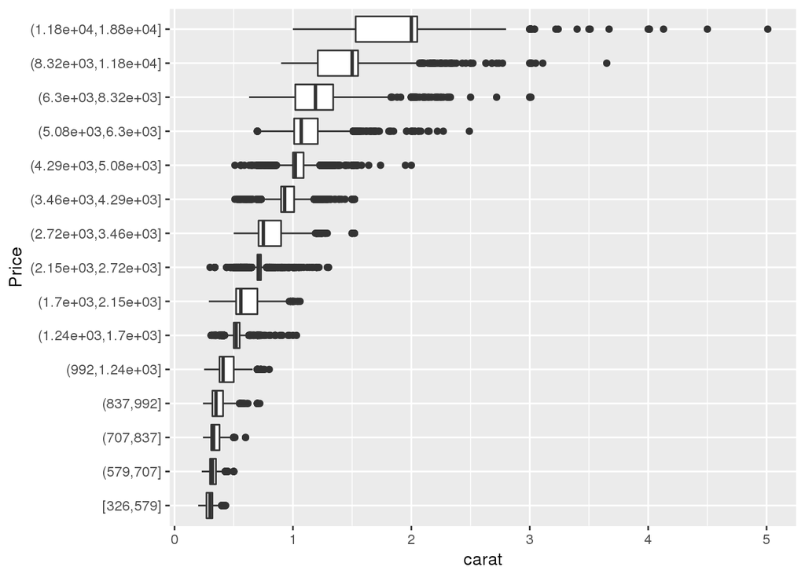

```r
#Use cut_number to partition by price
#n = 15 is the number of intervals

ggplot(diamonds, aes(x = cut_number(price, n = 15), y = carat)) +
  geom_boxplot() +
  coord_flip() +
  xlab("Price")
```

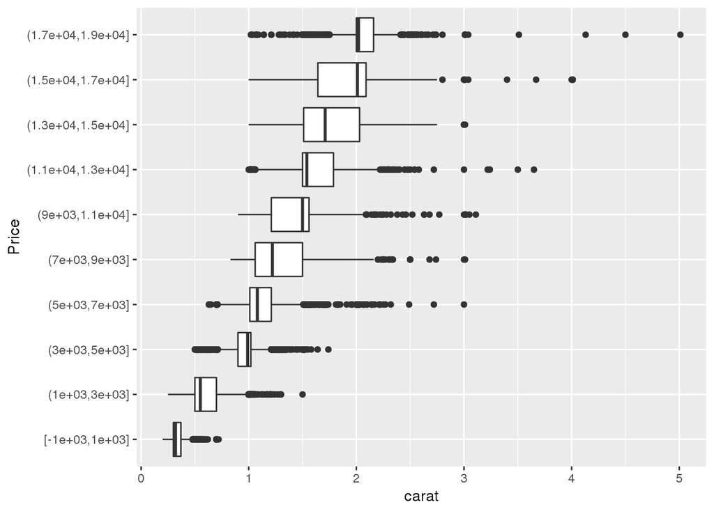

```r
#Can also use cut_width

ggplot(diamonds, aes(x = cut_width(price, 2000), y = carat)) +
  geom_boxplot() +
  coord_flip() +
  xlab("Price")
```

**3. How does the price distribution of very large diamonds compare to small diamonds. Is it as you expect, or does it surprise you?**

**4. Combine two of the techniques you’ve learned to visualise the combined distribution of cut, carat, and price.**

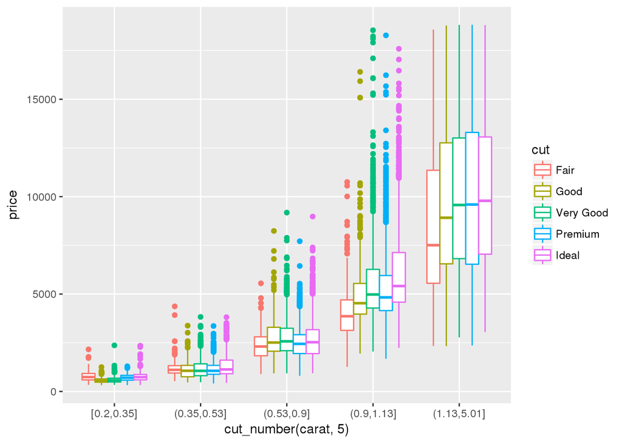

```r
ggplot(diamonds, aes(x = cut_number(carat, 5), y = price, color = cut)) +
  geom_boxplot()
```

**5. Two dimensional plots reveal outliers that are not visible in one dimensional plots. For example, some points in the plot below have an unusual combination of x and y values, which makes the points outliers even though their x and y values appear normal when examined separately. Why is a scatterplot a better display than a binned plot for this case?**

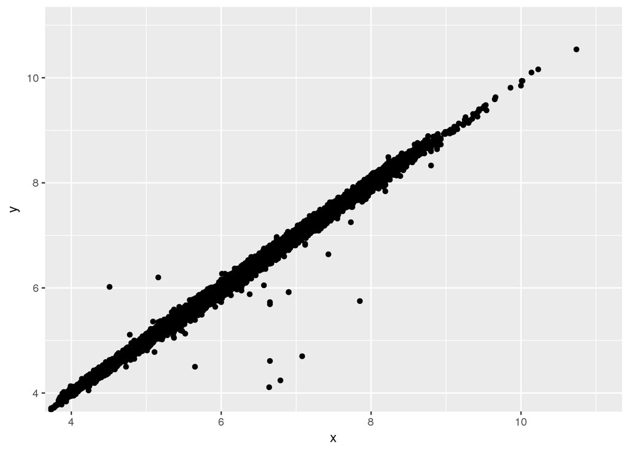

```r
#Given code is:

ggplot(data = diamonds) +
  geom_point(mapping = aes(x = x, y = y)) +
  coord_cartesian(xlim = c(4, 11), ylim = c(4, 11))
```

A scatterplot is better because visualizing this data with a bin plot (i.e. a histogram, like in Exercise 7.3.4) shows there are a few huge outliers in x and in y, which skews each histogram to the right. Exercise 7.3.4 shows the distributions for x and y are very similar (they are both highly right skewed by the handful of outliers in each dataset). However, when visualizing the relationship between y and x using a scatterplot, the scatterplot shows the relationship between y and x is strongly linear, despite the handful of huge outliers in x and in y that skew their distributions to the right. In the scatterplot, with the exception of a few points in the middle, the data points follow the linear line of best fit pretty well.

# Redo Hw 1 Qs using Tidyverse

Read in SNP and Individual Persons data

```r
#NOTE: do not use base R functions i.e. read.table because
#Base R functions are extremely slow. Tidyverse read in functions are a lot faster

SNP <- read_tsv(file = "/home/m280-data/hw1/merge-geno.bim", col_names = FALSE, quote = "\"")
#Tab separated

persons <- read_delim(file = "/home/m280-data/hw1/merge-geno.fam", delim = " ", col_names = FALSE)
#Space separated

#Rename columns in SNP
SNP <- rename(SNP, Chromosome = X1, SNP_ID = X2,
              Genetic_Distance = X3, BP = X4, Allele1 = X5,
              Allele2 = X6)

#Rename columns in Persons
persons <- rename(persons, FamilyID = X1, PersonID = X2, FatherID = X3,
                  MotherID = X4, Sex = X5, Affection_Status = X6)
```

**1. How many persons are in the data set (statisticians call this `n`)? How many SNPs are in the data set (statisticians call this `p`)?**

```r
#Each line is a SNP, so count the number of rows in SNP dataset.
count(SNP)
```

```
## # A tibble: 1 x 1
##         n
##     <int>
## 1 8348674
```

There are 8,348,674 SNPs in this dataset

```r
#Each line represents a unique individual, so count the number of rows in persons dataset
count(persons)
```

```
## # A tibble: 1 x 1
##       n
##   <int>
## 1   959
```

There are 959 people in this dataset

**2. Which chromosomes does this data set contain? How many SNPs are in each chromosome?**

```r
SNP1 <- distinct(SNP, Chromosome)
count(SNP1)
```

```
## # A tibble: 1 x 1
##       n
##   <int>
## 1    11
```

Calculate number of chromosomes by counting unique numbers in the first column. There are 11 unique numbers (specifically, 1, 3, 5, 7, …, 21) which means there are 11 chromosomes

```r
SNP %>%
  group_by(Chromosome) %>%
  summarize(., n())
```

```
## # A tibble: 11 x 2
##    Chromosome   `n()`
##         <int>   <int>
##  1          1 1309299
##  2          3 1215399
##  3          5 1090185
##  4          7  980944
##  5          9  732013
##  6         11  815860
##  7         13  602809
##  8         15  491208
##  9         17  477990
## 10         19  393615
## 11         21  239352
```

There are 1,309,299 SNPs in Chromosome 1, 1,215,399 SNPs in Chromosome 3, 1,090,185 SNPs in Chromosome 5, 980,944 SNPs in Chromosome 7, 732,013 SNPs in Chromosome 9, 815,860 SNPs in Chromosome 11, 602,809 SNPs in Chromosome 13, 491,208 SNPs in Chromosome 15, 477,990 SNPs in Chromosome 17, 393,615 SNPs in Chromosome 19 and 239,352 SNPs in Chromosome 21.

**3. MAP4 (microtubule-associated protein 4) is a gene on chromosome 3 spanning positions 47,892,180 bp – 48,130,769 bp. How many SNPs are located within MAP4 gene?**

```r
filter(SNP, Chromosome == 3 & (SNP$BP >= 47892180) & (SNP$BP <= 48130769)) %>%
  nrow()
```

```
## [1] 894
```

There are 894 SNPs located within MAP4 gene.

4. Statistical geneticists often have to reformat a data set to feed into various analysis programs. For example, to use the Mendel software http://www.genetics.ucla.edu/software/mendel, we have to reformat the data set to be read by Mendel.
   - Mendel’s SNP definition file is similar to the plink `bim` file but has format  
     `SNP ID`, `Chromosome`, `Base Pair Position`  
     with each field separated by a comma. Write a Linux shell command to convert `merge-geno.bim` to Mendel SNP definition file. The first few lines of the Mendel SNP definition file should look like

   ```r
   file("mendel_snpdef.txt")
   ```

   ```
   ## A connection with
   ## description "mendel_snpdef.txt"
   ## class       "file"
   ## mode        "r"
   ## text        "text"
   ## opened      "closed"
   ## can read    "yes"
   ## can write   "yes"
   ```

   ```r
   write_lines(c("     2.40 = FILE FORMAT VERSION NUMBER.", "8348674 = NUMBER OF SNPS LISTED HERE"), "mendel_snpdef.txt")

   SNP1 <- SNP %>%
     select(SNP_ID, Chromosome, BP)

   write_delim(SNP1, path = "mendel_snpdef.txt", delim = ",", append = TRUE, col_names = F)
   ```

   ```
   ##      2.40 = FILE FORMAT VERSION NUMBER.
   ## 8348674 = NUMBER OF SNPS LISTED HERE
   ## 1-54490,1,54490
   ## 1-55550,1,55550
   ## 1-57033,1,57033
   ## 1-57064,1,57064
   ## 1-57818,1,57818
   ## 1-58432,1,58432
   ## 1-58448,1,58448
   ## 1-58814,1,58814
   ```

   - Mendel’s pedigree file is similar to the plink `fam` file but has format  
     `Family ID`, `Person ID`, `Father ID`, `Mother ID`, `Sex` coded as M or F, `Twin Status`  
     with each field separated by a comma. Write a Linux shell command to convert `merge-geno.fam` to Mendel pedigree file. Since twin status is not available in plink format, we put nothing for that field. Also Mendel limits Person ID to have length less than or equal to 8 characters, so we have to strip the string `T2DG` from the IDs. First few lines of the Mendel pedigree should look like

   ```r
   persons$PersonID <- substr(persons$PersonID, 5, 11)
   persons$MotherID <- substr(persons$MotherID, 5, 11)
   persons$FatherID <- substr(persons$FatherID, 5, 11)

   persons1 <- persons %>%
     mutate(Sex = if_else(Sex == 1, "M", "F", missing = NULL)) %>%
     select(one_of(c("FamilyID", "PersonID", "FatherID", "MotherID", "Sex"))) %>%
     mutate(Twin_Status = "")
   write_delim(persons1, path = "mendel_persons.txt", delim = ",", append = FALSE, col_names = F)
   ```

   ```
   ## 2,0200001,,,M,
   ## 2,0200002,,,F,
   ## 2,0200003,,,F,
   ## 2,0200004,,,F,
   ## 2,0200005,,,M,
   ## 2,0200006,,,M,
   ## 2,0200007,,,F,
   ## 2,0200008,,,F,
   ## 2,0200009,,,F,
   ## 2,0200012,,,M,
   ## 2,0200013,,,M,
   ## 2,0200018,,,M,
   ## 2,0200023,,,F,
   ## 2,0200024,,,M,
   ## 2,0200027,,,F,
   ## 2,0200031,0200001,0200015,M,
   ## 2,0200032,0200001,0200015,F,
   ## 2,0200033,0200001,0200015,F,
   ## 2,0200034,0200001,0200015,F,
   ## 2,0200035,0200001,0200015,F,
   ```